# ES207_HW3

Erik Bolch

4. The Great Lakes Environmental Research Laboratory of the U.S. National Oceanic and Atmospheric Administration (NOAA-GLERL) routinely monitors the western basin of Lake Erie from May to October every year. The data file LakeErie1.csv includes all available data up to the end of 2014. Two variables are of particular interest in studying lake eutrophication. They are the total phosphorus (TP) and chlorophyll a (chla) concentrations. These are concentration variables and we often assume that their distributions are approximately normal.

Read the data into R and use the graphics to evaluate whether TP and chla are normally distributed.

```r
require(tidyverse)
```

```r
require(ggplot2)
erie <- read_csv("./data/LakeErie1.csv")
head(erie)
```

```
## # A tibble: 6 x 41
##   Station  Year Day   Date  Time  Latitude Longitude Depth Secchi  Temp
##   <chr>   <dbl> <chr> <chr> <drt>    <dbl>     <dbl> <dbl>  <dbl> <dbl>
## 1 LE1      2008 26-J~ 6/26~    NA     41.8      83.1    NA    3.4    NA
## 2 LE2      2008 26-J~ 6/26~    NA     41.8      83.2    NA    4.9    NA
## 3 LE3      2008 26-J~ 6/26~    NA     41.8      83.4    NA    3.2    NA
## 4 LE4      2008 26-J~ 6/26~    NA     41.7      83.4    NA    2.2    NA
## 5 LE5      2008 26-J~ 6/26~    NA     41.7      83.5    NA    0.2    NA
## 6 LE6      2008 26-J~ 6/26~    NA     41.7      83.3    NA    1.4    NA
## # ... with 31 more variables: Co0 <dbl>, SpCo0 <dbl>, BeamAtten <dbl>,
## #   Transmission <dbl>, chla <dbl>, PC <dbl>, PAR <dbl>, DO <dbl>,
## #   au.chl <dbl>, AquaFluor_PC <dbl>, AquaFluor_CHL <dbl>,
## #   Turbidity <dbl>, TP <dbl>, TDP <dbl>, SRP <dbl>, NH4 <dbl>, NO3 <dbl>,
## #   SiO2 <dbl>, Cl <dbl>, TSS <dbl>, VSS <dbl>, POC <dbl>, PON <dbl>,
## #   DOC <dbl>, ExChla <dbl>, ExPC <dbl>, pMC <dbl>, dMC <dbl>,
## #   pMC_LC_MS <dbl>, TCyanos_cells <dbl>, TCyanos_volume <dbl>
```

### TSS Histogram/QQPlot

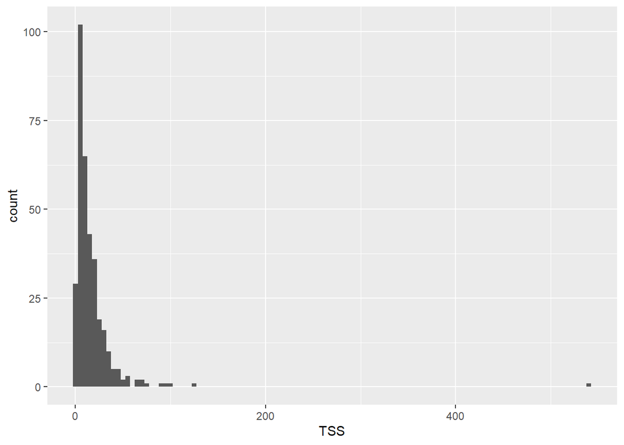

```r
erie %>%
  ggplot(aes(TSS))+ geom_histogram(binwidth = 5, na.rm = T)
```

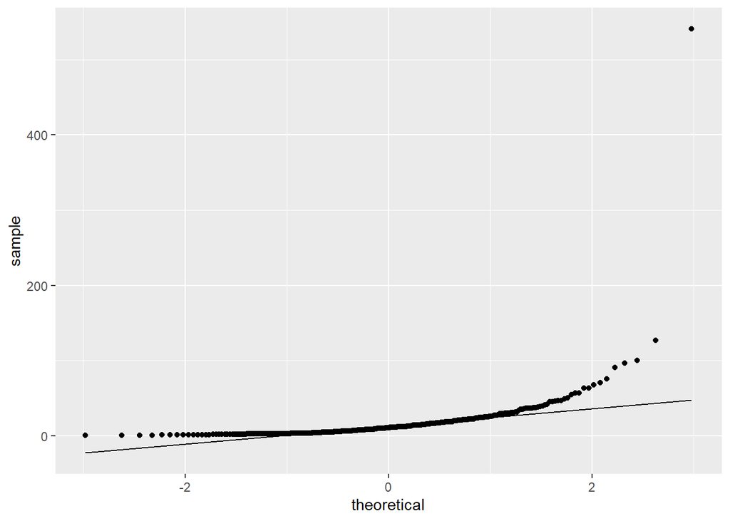

```r
erie %>%
  ggplot(.,aes(sample = TSS))+
    geom_qq(na.rm = T) + geom_qq_line(na.rm = T)
```

### Chla Histogram/QQPlot

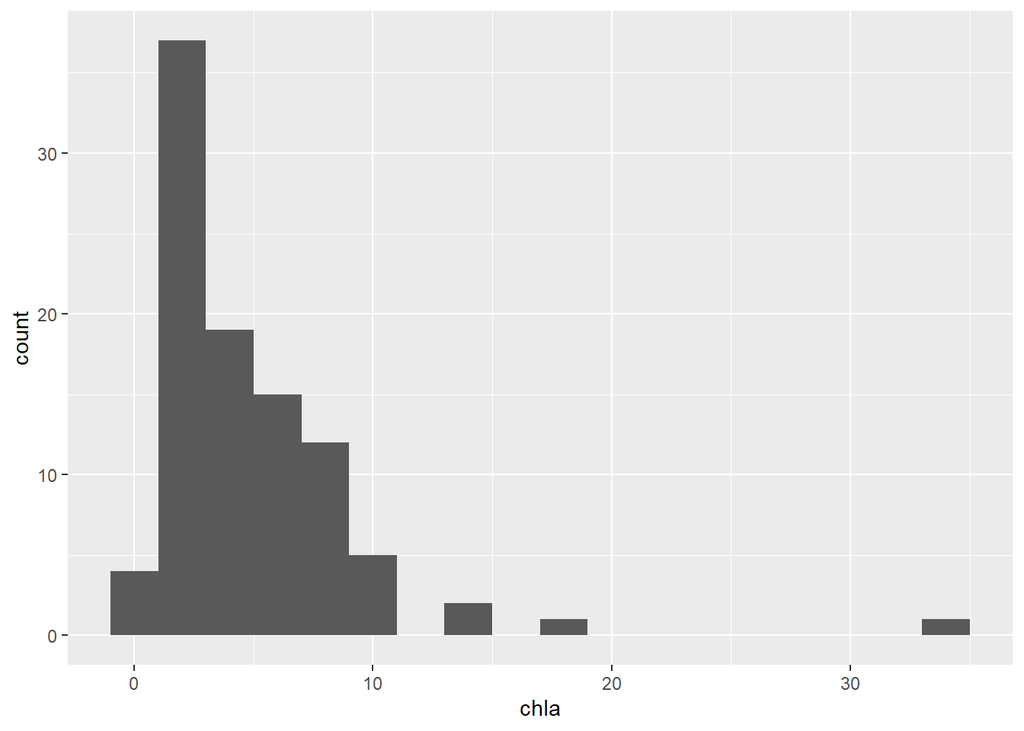

```r
erie %>%
  ggplot(aes(chla)) + geom_histogram(binwidth = 2, na.rm = T)
```

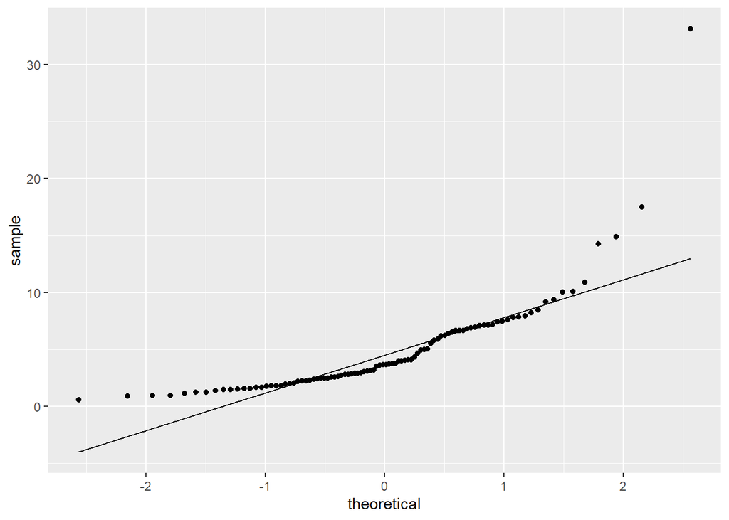

```r
erie %>%
  ggplot(.,aes(sample = chla))+
    geom_qq(na.rm = T) + geom_qq_line(na.rm = T)
```

These distributions don’t look normal, they are skewed, which is typical of an environmental dataset.

Western Lake Erie’s nutrient concentrations are largely associated with Maumee River input, which varies from year to year due to variation in weather conditions. As a result, we expect that TP, as well as chla, concentration distributions vary by year. Use the function qqmath (from package lattice) to draw normal Q-Q plots of TP and chla concentrations by year. Are the annual concentration distributions closer to being normal?

```r
require(lattice)
```

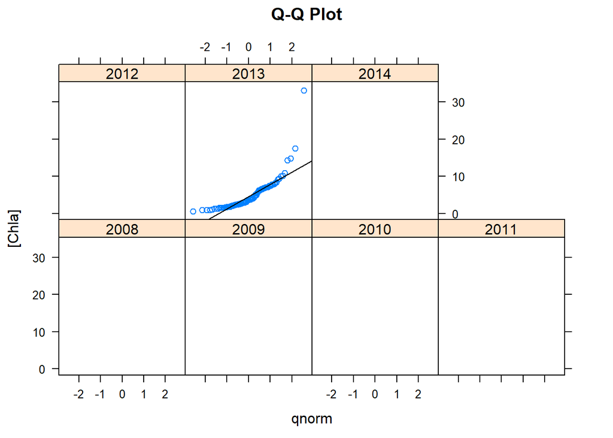

```r
z<-qqmath(~chla | factor(Year), data = erie, distribution = qnorm, main = "Q-Q Plot",  ylab = "[Chla]",
          panel = function(x, ...) {
            panel.qqmath(x, ...)
            panel.qqmathline(x, ...)
            })
plot(z)
```

Chla concentration data only exists for 1 year (2013), plotted above. The log normal distribution is skewed, because the values depart from the q-q line at each end, meaning there are more values above and below the mean. In a normal distribution the majority of values would be located on or close to the mean.

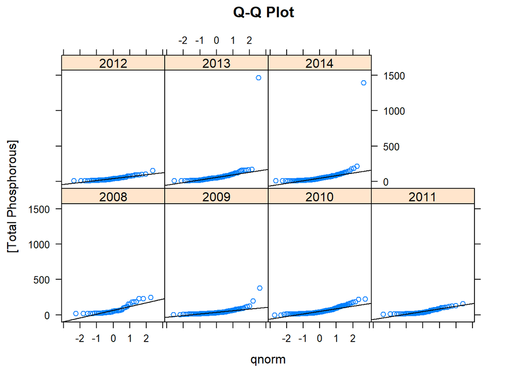

```r
y<-qqmath(~TP | factor(Year), data = erie,  distribution = qnorm, main = "Q-Q Plot", ylab = "[Total Phosphorous]",
          panel = function(x, ...) {
            panel.qqmath(x, ...)
            panel.qqmathline(x, ...)
            })

plot(y)
```

Even after separating by year, the sampled data have a slight curve at both ends, indicating a skewed distribution.

5. In addition to NOAA-GLERL, several other institutions also have routine monitoring programs on Lake Erie. Data file LakeErie2.csv contains TP and chla concentration data collected by NOAA-GLERL, Ohio Department of Natural Resources (ODNR), and The University of Toledo (Toledo).
1. Compare the distribution of the TP concentration data from NOAA to the same from ODNR:

Are the two distributions different?

```r
erie.2 <- read_csv("./data/LakeErie2.csv")
```

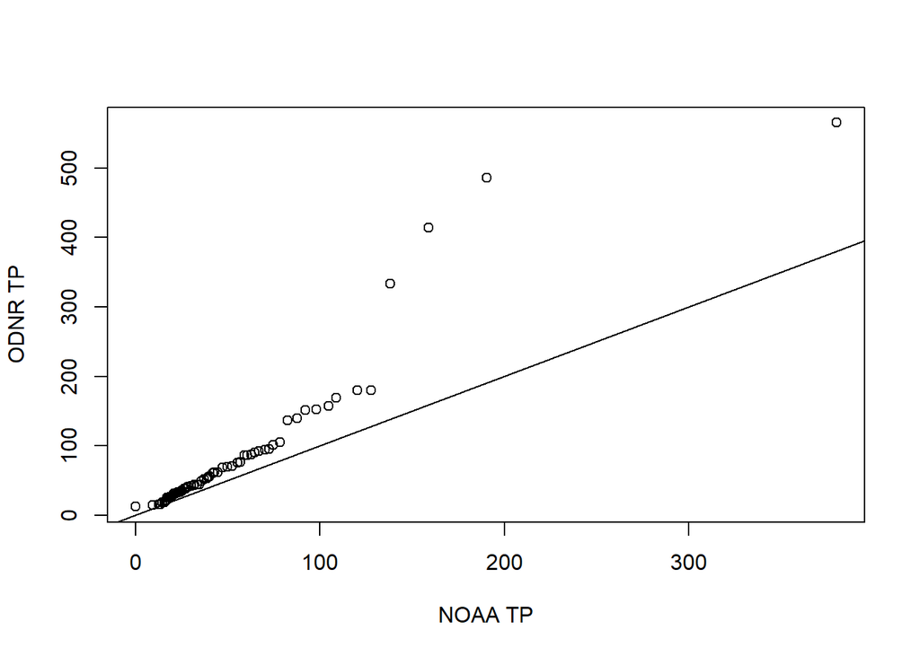

```r
erie.2s<-split(erie.2,erie.2$INSTITUTION)

erie.2.NOAA<- erie.2s[[1]]
erie.2.ODNR<- erie.2s[[2]]
erie.2.tol<- erie.2s[[3]]

qqplot(erie.2.NOAA$TP,erie.2.ODNR$TP, xlab = "NOAA TP", ylab = "ODNR TP")
abline(0,1)
```

Yes, the distributions are different, they do not fall along a line line with a slope of 1.

If so, is the difference between the two TP concentration distributions more likely to be additive or multiplicative?

The difference is more likely to be multiplicative because the points have a higher slope than approximately 1, not just a higher intercept as would be expected for additive.

Are the variances of the two distributions the same?

```r
var(erie.2.NOAA$TP, na.rm = T)
```

```
## [1] 1996.333
```

```r
var(erie.2.ODNR$TP, na.rm = T)
```

```
## [1] 11093.93
```

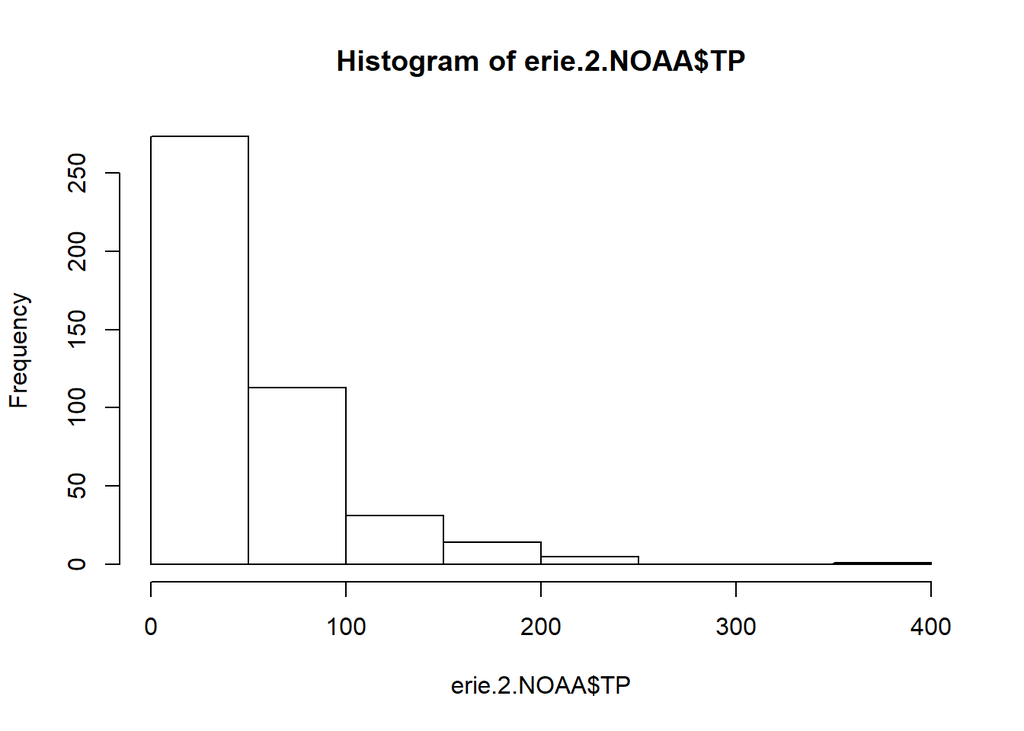

```r
hist(erie.2.NOAA$TP)
```

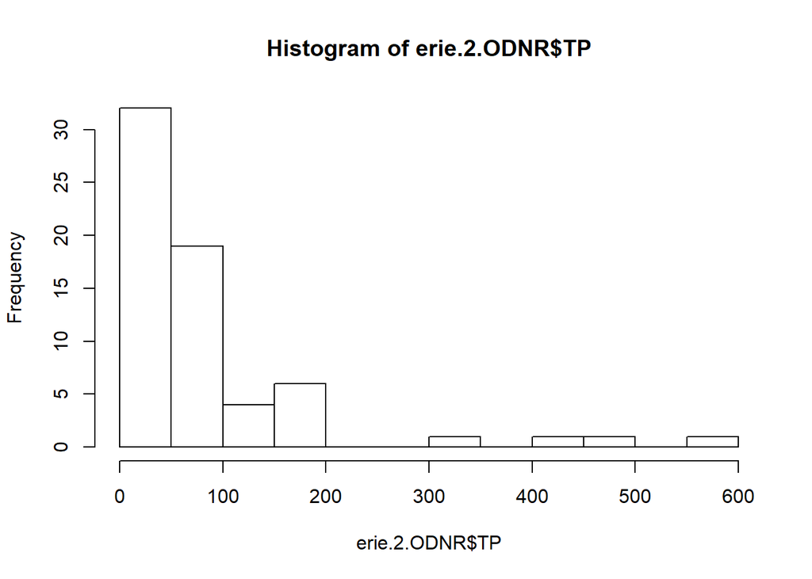

```r
hist(erie.2.ODNR$TP)
```

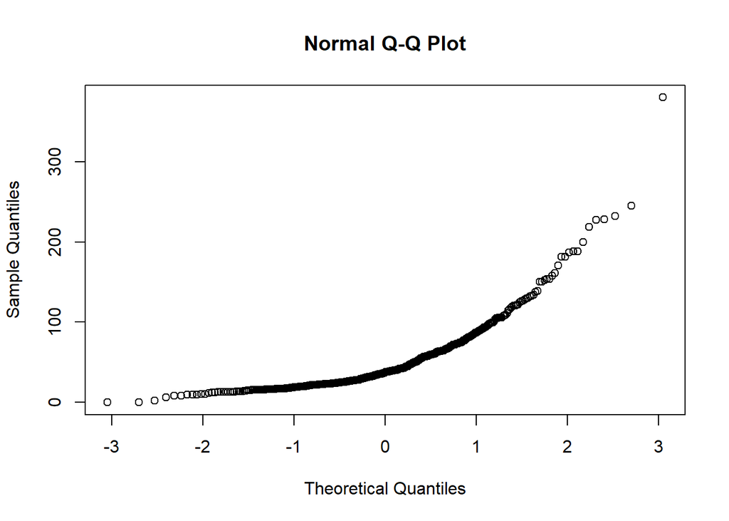

```r
qqnorm(erie.2.NOAA$TP)
```

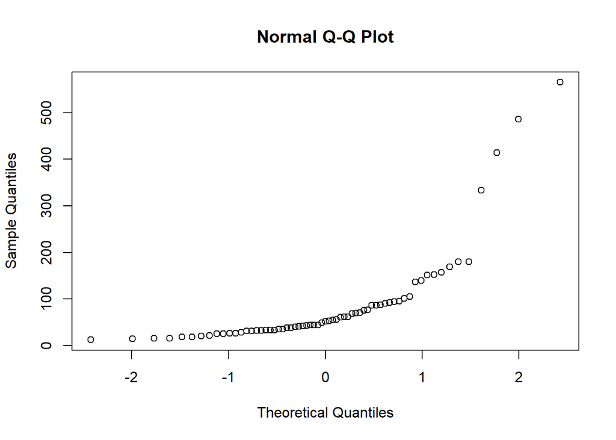

```r
qqnorm(erie.2.ODNR$TP)
```

The variances are quite different, the ODNR variance being higher by a factor of 5. This the the result of being a smaller sample size, with a couple very high samples, which is greatly impacting the distribution.

3. Repeat the previous comparison to compare TP distributions from Toledo and NOAA, and ODNR and Toledo, and summarize the results.

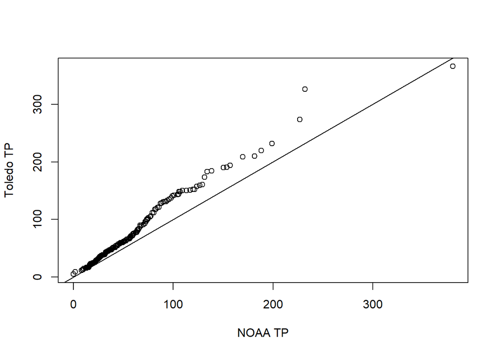

```r
qqplot(erie.2.NOAA$TP,erie.2.tol$TP, xlab = "NOAA TP", ylab = "Toledo TP")
abline(0,1)
```

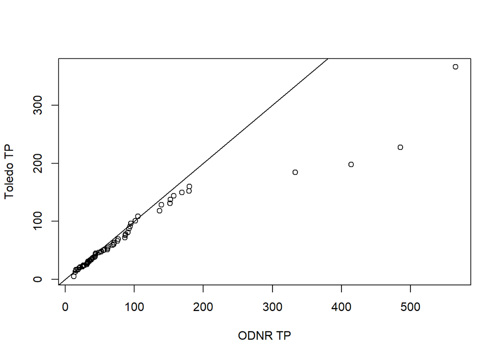

```r
qqplot(erie.2.ODNR$TP,erie.2.tol$TP, xlab = "ODNR TP", ylab = "Toledo TP")
abline(0,1)
```

The NOAA and Toledo TP concentrations appear to have more similar distributions than the NOAA and ODNR data. They are still multiplicative due to the increased slope of the points as TP concentration increases at both sites.

The ODNR and Toledo TP concentrations appear to also have a multiplicative difference in distribution, however, because of the axes, the slope is lower than 1 instead of higher. Also, the 4 or 5 very high TP concentrations from the ODNR dataset are drastically affecting the distribution making it harder to discern the difference. Whether they are abnormally high due to some event, or are bad data they have a large impact on the distribution of that dataset.

7. Figure 3.16 explores the dependency of the ozone concentration-solar radiation relationship on wind speed and temperature. Use the same conditional plot to examine the dependency of the ozone concentration-temperature relationship on wind speed and solar radiation, and the ozone concentration-wind speed relationship on solar radiation and temperature.

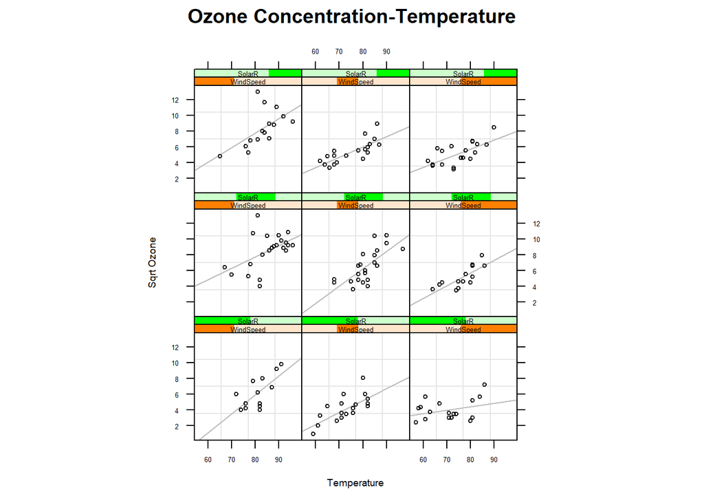

```r
require(lattice)

WindSpeed <- equal.count(airquality$Wind, 3, 0.25)
Temperature <- equal.count(airquality$Temp, 3, 0.25)
SolarR <- equal.count(airquality$Solar.R, 3, 0.25)
print(
  xyplot(sqrt(Ozone) ~ Temperature|WindSpeed*SolarR,
         data=airquality,
         panel=function(x,y,...){
           #            panel.loess(x, y, span=1, degree=1, ...)
           panel.grid()
           panel.lmline(x, y, col="grey",...)
           panel.xyplot(x, y, col=1, cex=0.5, ...)
         },
         main="Ozone Concentration-Temperature",
         ylab=list(label="Sqrt Ozone", cex=0.6),
         xlab=list(label="Temperature", cex=0.6),
         scales=list(x=list(alternating=c(1, 2, 1))),
         #       between=list(y=1),
         par.strip.text=list(cex=0.4), aspect=1,
         par.settings=list(axis.text=list(cex=0.4)))
)
```

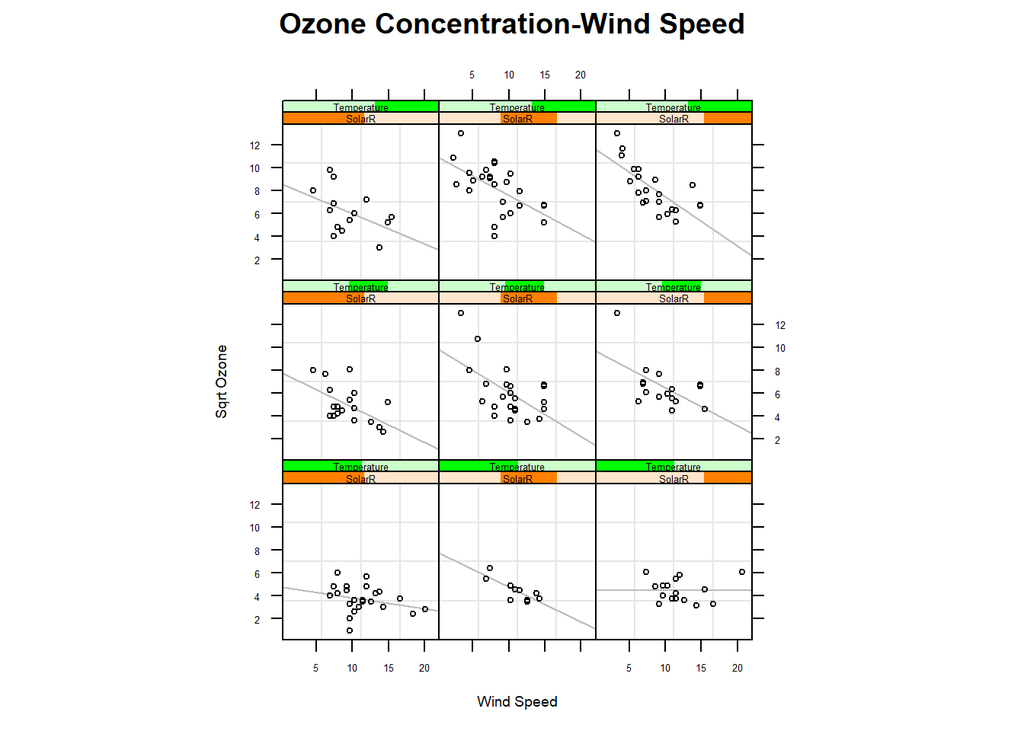

```r
print(
  xyplot(sqrt(Ozone) ~ WindSpeed|SolarR*Temperature,
         data=airquality,
         panel=function(x,y,...){
           #            panel.loess(x, y, span=1, degree=1, ...)
           panel.grid()
           panel.lmline(x, y, col="grey",...)
           panel.xyplot(x, y, col=1, cex=0.5, ...)
         },
         main="Ozone Concentration-Wind Speed",
         ylab=list(label="Sqrt Ozone", cex=0.6),
         xlab=list(label="Wind Speed", cex=0.6),
         scales=list(x=list(alternating=c(1, 2, 1))),
         #       between=list(y=1),
         par.strip.text=list(cex=0.4), aspect=1,
         par.settings=list(axis.text=list(cex=0.4)))
)
```

Both Temperature, and Wind speed appear to have monotonic relationships with the sqrt transformed Ozone concentration, though higher temperature corresponds with higher Ozone, while higher wind speed corresponds with lower Ozone.

For the plot of Ozone Conc-Temperature, in the majority of cases that wind speed increases, the strength of the relationship between Ozone Conc and temperature seems to decrease, as indicated by the decreasing slope of the lines, with the exception of the center row (mid Solar R). This suggests that there may be a relationship, but its unclear. As for the effect of Solar R, on the Ozone-Temp relationship, theres not sufficient evidence to suggest a dependency.

For the plot of Ozone Conc-Windspeed the strength of the ozone-wind relationship appears to increase in strength (steeper slopes) as Solar R increases at high temperatures, but almost appears to do the opposite at lower temperatures, and seems to have no effect a mid-range temperatures. Increases in temperature seem to have a stronger effect on the ozone-wind relationship at high Solar R. In either case I don’t think theres sufficient evidence to suggest a dependency as exists in the original 3.16 plot, where Temp and Windspeed have a clear effect on the relationship between Ozone Concentration and Solar radiation.